# xv20220927_4_BRCA2_tumors

x.vergara

2022-09-28

#Intro: This figure corresponds to figure #4 in the main text.

Fig. 4. BRCA2 +/+ and BRCA2 -/- tumor analysis

Fig. 4. Impact on mutation distribution in cancer genomes. (A) Total MMEJ and NHEJ signature in-del log2 ratio in euchromatin (Eu.) and constitutive lamina-associated heterochromatin (Het.) of BRCA2-positive (BRCA2+/+, n = 22) and BRCA2 deficient tumors (BRCA2-/-, n = 41). p-values are calculated by Fisher’s count test on total deletion signatures per tumor type (Fig. S8B-C). (B) Cartoon illustrating BRCA2 N-synergy.

#Script set-up

```r
knitr::opts_chunk$set(root.dir = '/home/x.vergara/XV_P3_ChromDSBScreen/xv_CRISPR_screen_figures/rmarkdown/xv20210920_paper_scripts/short_version/knit_html/')

StartTime <-Sys.time()
library(knitr)

# 8-digit Date tag:
Date <- substr(gsub("-","",Sys.time()),1,8)

#Change in.dir accordingly
in.dir <- "/home/x.vergara/XV_P3_ChromDSBScreen/xv_CRISPR_screen_figures/"

#Check if output contain datetag
saveRDS_proof <- function(object, file) {
  document_path <- rstudioapi::getSourceEditorContext()$path %>% str_split(pattern = "/") %>% unlist()
  document_name <- document_path[length(document_path)]
  sys_time <- Sys.time()
  if (grepl(Date, file) == T) {
    saveRDS(object, file)
    #write(c(document_name, as.character(sys_time),"Output", correct_file), file = paste0(in.dir,"log"), ncolumns = 4, sep = "\t", append = T)
  }
  else {
    print("Incorrect datetag!")
  }
}

#Read rds check through different versions
readRDS_proof <- function(path, pat) {
  full.path <- paste0(in.dir, path)
  document_path <- rstudioapi::getSourceEditorContext()$path %>% str_split(pattern = "/") %>% unlist()
  document_name <- document_path[length(document_path)]
  sys_time <- Sys.time()

  if(file.exists(full.path) == T){
    if(paste0(in.dir,path) != getwd()){
      setwd(paste0(in.dir, path))
  }
    file.list <- list.files(pattern = pat)
    correct_file <- str_sort(file.list, decreasing = T)[1]
    print(correct_file)
    base::readRDS(file = correct_file)
    #write(c(document_name,as.character(sys_time) ,"Input", correct_file), file = paste0(in.dir,"log"), ncolumns = 4, sep = "\t", append = T)

  }
  else{
  setwd(path)
  file.list <- list.files(pattern = pat)
  correct_file <- str_sort(file.list, decreasing = T)[1]
  print(correct_file)
  base::readRDS(file = correct_file)
  #write(c(document_name, as.character(sys_time),"Input", correct_file),file = paste0(in.dir,"log"), ncolumns = 4, sep = "\t", append = T)
  }
}
```

# Libraries

```r
# setwd
setwd(in.dir)

# libraries:
library(tidyverse)
library(reshape2)
library(broom)
library(ggrepel)
library(dendextend)
```

```r
library(umap)
library(igraph)
library(lsa)
library(tibble)
library(utils)
library(base)
library(scales)
```

# Input files for this script: Data needed for figure 4 and come from the processed_data directory

```r
# setwd
setwd(in.dir)

#Print note:
print(paste("The following datasets will be loaded for this script:"))
```

```
## [1] "The following datasets will be loaded for this script:"
```

```r
#Tumor analysis
indel_data_tumors <- readRDS_proof("data/processed_data/","SCC_indel_MMEJ_NHEJ")
```

```
## [1] "xv20220922_SCC_indel_MMEJ_NHEJ_deletions.rds"
```

1. Total MMEJ and NHEJ signature in-del log2 ratio in euchromatin (Eu.) and constitutive lamina-associated heterochromatin (Het.) of BRCA2-positive (BRCA2+/+, n = 22) and BRCA2 deficient tumors (BRCA2-/-, n = 41). p-values are calculated by Fisher’s count test on total deletion signatures per tumor type (Fig. S8B-C).

#Preparatory chunk: Prepare BRCA2-/- data for plotting and compute statistics

```r
distribution_tumor_indel_pathway <- indel_data_tumors %>%
  filter(ciLAD == 1 | cLAD == 1) %>%
  mutate(LAD_status = case_when(ciLAD == 1 ~ "ciLAD",
                                cLAD == 1 ~ "cLAD")) %>%
  dplyr::group_by(tumor_type, tumor_id, LAD_status, total_mutation, CLASS) %>% dplyr::summarise(mut_count = n(), .groups = "drop") %>%
  reshape2::dcast(tumor_type + tumor_id + total_mutation + LAD_status ~ CLASS, value.var = "mut_count", fill = 0) %>%
dplyr::group_by(tumor_type, LAD_status) %>%
  dplyr::summarise(log2_ratio = log2(sum(MMEJ, na.rm = T)/sum(cNHEJ, na.rm = T)))
distribution_tumor_indel <- indel_data_tumors %>%
  filter(ciLAD == 1 | cLAD == 1) %>%
  mutate(LAD_status = case_when(ciLAD == 1 ~ "ciLAD",
                                cLAD == 1 ~ "cLAD")) %>%
  dplyr::group_by(tumor_type, LAD_status, CLASS) %>% dplyr::summarise(mut_count = n(), .groups = "drop") %>%
  reshape2::dcast(tumor_type + CLASS ~ LAD_status, value.var = "mut_count", fill = 0)
```

#Figure 4A: Mutation accumulation in BRCA2mut and sporadic HNSCC (Option A)

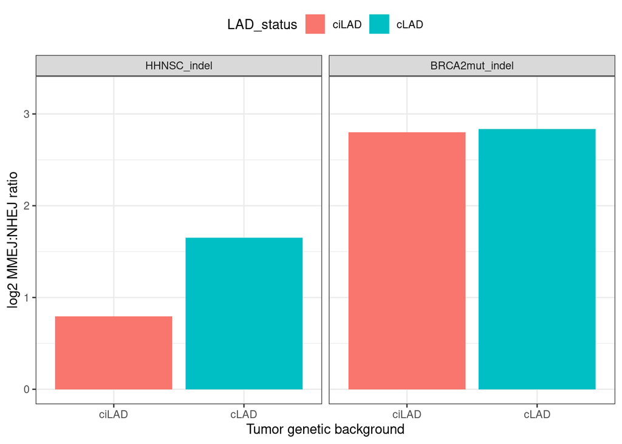

```r
#Plot A in figure 4 (pathway perspective)
ggplot(distribution_tumor_indel_pathway) + geom_col(aes(LAD_status,log2_ratio, fill = LAD_status)) + facet_wrap(~ fct_relevel(tumor_type, c("HHNSC_indel","BRCA2mut_indel"))) + theme_bw() + theme(legend.position = "top") + xlab("Tumor genetic background") + ylab("log2 MMEJ:NHEJ ratio") + coord_cartesian(ylim = c(0,3.25))
```

```r
#chi squared test for all these cases
#cNHEJ
BRCA2_fisher <- distribution_tumor_indel %>% ungroup() %>% filter(tumor_type == "BRCA2mut_indel") %>% dplyr::select(-tumor_type) %>% column_to_rownames(var = "CLASS") %>% fisher.test() %>% tidy()
#MMEJ
HNSC_fisher <- distribution_tumor_indel %>% ungroup() %>% filter(tumor_type == "HHNSC_indel") %>% dplyr::select(-tumor_type) %>% column_to_rownames(var = "CLASS") %>% fisher.test() %>% tidy()
```